# BIRAX study - TASMC cohort construction

David M Wright - d.wright@qub.ac.uk

Document compiled: 2023-07-03

R version 4.3.0 (2023-04-21 ucrt)

# 1 Introduction

This analysis is of Electronic Medical Records (EMR) from the Tel Aviv Sourasky Medical Centre extracted over the period 2014-04-27 to 2022-07-31. The aim of the study is to investigate the potential for machine learning to identify factors and biomarkers associated with long-term AMD treatment response.

This document describes construction of the analysis cohort.

# 2 Data sources

Three data files were provided, `MDC_Updated_16062023_anon_david.xslx` contained the clinical records of all injections, OCT scans and VA measurements (MD Clone data). `Notal+MDC with additional IDs 16062023_anon_david.xslx` and `Results Notal_with original IDs_and_anon_185.xslx` contained the fluid measurements derived from OCT scans using the Notal Ophthalmic Analyser (NOA). All files were converted to .csv format before further processing.

# 3 Cohort construction

The following steps were taken to process the data:

Injections

- Identification of the first injection recorded for each eye and the date (the index date).
- Calculation of treatment intervals.
- Calculate the total time under treatment.
- Indicate the year of treatment for each injection (from the index date, starting at 1).

Patient demographics

Visual acuity

- Categorisation of visual acuity into 4 Snellen categories (calculations in logMAR units).
- Identified baseline VA measurement (closest measurement to index date: earliest date 40 days prior, could not occur after index date).
- At each VA measurement calculate VA change (logMAR) since the baseline (index date).
- Categorise VA change since baseline in ETDRS lines (calculations in logMAR units)).
- Identification of the closest VA measurement to each time point of interest during treatment.

Fluid measurements

- Identified baseline fluid measurement (closest measurement to index date: earliest date 40 days prior, could not occur after index date).
- Identification of the closest fluid measurement to each time point of interest during treatment.
- Categorised AMD type at each fluid measurement: None/SRF only/IRF only/Both SRF and IRF.

## 3.1 Inclusion and exclusion criteria

EMR for a total of 997 patients were included in the extracted dataset, with 18518 records of anti-VEGF injections. The unit of analysis is the eye but some criteria were applied at the patient level:

- Excluded 44 patients that were involved in a clinical trial and so received different treatments from the majority of patients.
- Excluded 67 patients that were first treated during the Covid pandemic, a substantially different group of patients.

At the eye level:

A total of 1024 eyes from 821 patients remained after these exclusions. A total of 18279 injections were observed for the cohort, allowing 17255 treatment intervals to be observed (between injections).

# 4 Descriptive statistics at baseline

Descriptive statistics for the eyes included in the analysis are given in Tables 4.1 to 4.18. Statistics are presented at the eye level as some patients were treated in both eyes, with treatment starting at different times.

## 4.1 Patient characteristics

Table 4.1: Baseline characteristics of eyes with AMD. Frequency and percentage reported for categorical variables.

| Variable | Level | Value | n |
| --- | --- | --- | --- |
| Age | Mean (Range) | 80.6 (50.1, 107) | NA |
| GENDER | F | NA | 583 (56.9%) |
| GENDER | M | NA | 441 (43.1%) |
| Eyes |  | NA | 1024 (100%) |

A key characteristic of the dataset is the different lengths of follow-up overall (i.e. time period for which records were extracted), in terms of treatment duration and in terms of monitoring for each examination type, given in Table 4.2. There are several different measures presented:

- *Years observed* gives the time from the first injection (baseline) to the the last recorded injection or the last recorded VA measurement, whichever was longer.
- *Years treated* gives the time from the first injection to the last recorded injection.
- *VA years observed* gives the time from the first injection to the last recorded VA measurement.

Table 4.2: Number of examinations and length of follow-up.

| Variable | Level | n | Value |
| --- | --- | --- | --- |
| Eyes |  | 1024 (100%) | NA |
| Years observed | Median (Range) | NA | 2.84 (0.153, 5.44) |
| Total injections |  | NA | 18279 (100%) |
| Injections | Median (Range) | NA | 16 (3, 58) |
| Years treated | Median (Range) | NA | 2.31 (0.153, 5.44) |
| Total VA exams |  | 12320 (100%) | NA |
| VA exams | Median (Range) | NA | 11 (1, 46) |
| VA years observed | Median (Range) | NA | 2.77 (0, 5.44) |
| VA years observed | Mean (SD) | NA | 2.75 (1.44) |
| Total OCT fluid measurements |  | 9168 (100%) | NA |
| OCT fluid measurements | Median (Range) | NA | 8 (1, 29) |
| OCT fluid years observed | Median (Range) | NA | 2.23 (0, 4.76) |

## 4.2 Follow-up by treatment year

Table 4.3: Distribution of injections received by year of anti-VEGF treatment

| Variable | Level | 1 | 2 | 3 | 4 | 5 | 6 |
| --- | --- | --- | --- | --- | --- | --- | --- |
| Injections | Mean (SD) | 7.29 (2.62) | 6.1 (2.84) | 5.81 (3.02) | 5.4 (3.19) | 4.91 (2.96) | 2.25 (1.33) |
| Injections | Median (Range) | 8 (1, 13) | 6 (1, 13) | 6 (1, 13) | 5 (1, 14) | 4 (1, 12) | 2 (1, 5) |
| Eyes |  | 1024 (100%) | 752 (100%) | 557 (100%) | 365 (100%) | 184 (100%) | 52 (100%) |

Table 4.4: Distribution of injections received by year of anti-VEGF treatment and fluid type at baseline

| amd_type | Variable | Level | 1 | 2 | 3 | 4 | 5 | 6 |
| --- | --- | --- | --- | --- | --- | --- | --- | --- |
| No fluid | Eyes |  | 116 (100%) | 74 (100%) | 58 (100%) | 51 (100%) | 29 (100%) | 13 (100%) |
| No fluid | Injections | Mean (SD) | 6.18 (2.64) | 5.95 (2.65) | 6.21 (2.84) | 5.1 (3.08) | 5.14 (3.08) | 2 (1.35) |
| No fluid | Injections | Median (Range) | 6 (1, 12) | 6 (1, 11) | 6 (1, 11) | 4 (1, 11) | 5 (1, 11) | 1 (1, 5) |
| SRF only | Eyes |  | 228 (100%) | 179 (100%) | 133 (100%) | 90 (100%) | 46 (100%) | 9 (100%) |
| SRF only | Injections | Mean (SD) | 7.68 (2.63) | 6.44 (2.82) | 6.52 (3.07) | 5.94 (3.32) | 4.98 (3.04) | 2 (1.58) |
| SRF only | Injections | Median (Range) | 8 (1, 13) | 7 (1, 12) | 7 (1, 13) | 6 (1, 12) | 4 (1, 11) | 1 (1, 5) |
| IRF only | Eyes |  | 191 (100%) | 139 (100%) | 104 (100%) | 60 (100%) | 31 (100%) | 12 (100%) |
| IRF only | Injections | Mean (SD) | 7.1 (2.51) | 5.81 (2.91) | 5.46 (2.94) | 5.47 (3.26) | 4.74 (3.12) | 2.83 (1.4) |
| IRF only | Injections | Median (Range) | 8 (1, 12) | 6 (1, 11) | 5 (1, 12) | 5 (1, 14) | 4 (1, 12) | 2.5 (1, 5) |
| SRF and IRF | Eyes |  | 416 (100%) | 318 (100%) | 228 (100%) | 138 (100%) | 62 (100%) | 15 (100%) |
| SRF and IRF | Injections | Mean (SD) | 7.63 (2.59) | 6.19 (2.87) | 5.53 (3.09) | 5.41 (3.16) | 5.18 (2.8) | 2.07 (1.03) |
| SRF and IRF | Injections | Median (Range) | 8 (1, 12) | 6 (1, 13) | 5 (1, 12) | 5 (1, 12) | 5 (1, 11) | 2 (1, 4) |

Table 4.5: Distribution of VA measurements by year of anti-VEGF treatment

| Variable | Level | 1 | 2 | 3 | 4 | 5 | 6 |
| --- | --- | --- | --- | --- | --- | --- | --- |
| VA measurements | Mean (SD) | 4.06 (2.08) | 3.93 (2.04) | 3.41 (1.88) | 3.29 (1.77) | 2.8 (1.66) | 1.62 (0.986) |
| VA measurements | Median (Range) | 4 (1, 17) | 4 (1, 15) | 3 (1, 14) | 3 (1, 17) | 3 (1, 9) | 1 (1, 6) |
| Eyes |  | 988 (100%) | 840 (100%) | 670 (100%) | 441 (100%) | 230 (100%) | 61 (100%) |

Table 4.6: Distribution of VA measurements by year of anti-VEGF treatment

| amd_type | Variable | Level | 1 | 2 | 3 | 4 | 5 | 6 |
| --- | --- | --- | --- | --- | --- | --- | --- | --- |
| No fluid | VA measurements | Mean (SD) | 4.38 (1.96) | 4.27 (2.44) | 3.34 (1.72) | 3.09 (1.63) | 2.57 (1.64) | 1.62 (0.65) |
| No fluid | VA measurements | Median (Range) | 4 (1, 11) | 4 (1, 15) | 3 (1, 12) | 3 (1, 8) | 2 (1, 8) | 2 (1, 3) |
| No fluid | Eyes |  | 107 (100%) | 95 (100%) | 80 (100%) | 58 (100%) | 37 (100%) | 13 (100%) |
| SRF only | VA measurements | Mean (SD) | 3.96 (1.77) | 4.02 (1.99) | 3.43 (1.88) | 3.13 (1.52) | 2.61 (1.37) | 1.44 (0.527) |
| SRF only | VA measurements | Median (Range) | 4 (1, 13) | 4 (1, 14) | 3 (1, 13) | 3 (1, 8) | 3 (1, 7) | 1 (1, 2) |
| SRF only | Eyes |  | 222 (100%) | 192 (100%) | 155 (100%) | 108 (100%) | 56 (100%) | 9 (100%) |
| IRF only | VA measurements | Mean (SD) | 4.15 (2.16) | 3.8 (1.78) | 3.51 (1.87) | 3.34 (2.07) | 2.84 (1.59) | 1.85 (1.07) |
| IRF only | VA measurements | Median (Range) | 4 (1, 13) | 4 (1, 10) | 3 (1, 10) | 3 (1, 17) | 3 (1, 9) | 1 (1, 4) |
| IRF only | Eyes |  | 186 (100%) | 168 (100%) | 131 (100%) | 79 (100%) | 38 (100%) | 13 (100%) |
| SRF and IRF | VA measurements | Mean (SD) | 4.05 (2.24) | 3.86 (2.03) | 3.34 (1.97) | 3.36 (1.82) | 3.04 (1.82) | 1.68 (1.29) |
| SRF and IRF | VA measurements | Median (Range) | 4 (1, 17) | 4 (1, 15) | 3 (1, 14) | 3 (1, 10) | 3 (1, 8) | 1 (1, 6) |
| SRF and IRF | Eyes |  | 404 (100%) | 338 (100%) | 266 (100%) | 166 (100%) | 77 (100%) | 22 (100%) |

## 4.3 Visual acuity

Table 4.7: Distribution of visual acuity outcomes at baseline.

| Description | Level | Value | n |
| --- | --- | --- | --- |
| Visual acuity (LogMAR) | Median (IQR) | 0.46 (0.19, 0.96) | NA |
| Eyes | n | NA | 982 (100%) |

Table 4.8: Distribution of visual acuity outcomes at baseline by fluid presence.

| Description | Level | No fluid | SRF only | IRF only | SRF and IRF |
| --- | --- | --- | --- | --- | --- |
| Visual acuity (LogMAR) | Median (IQR) | 0.26 (0.18, 0.66) | 0.26 (0.18, 0.5) | 0.48 (0.19, 0.96) | 0.66 (0.36, 1.34) |
| Eyes | n | 109 (100%) | 226 (100%) | 189 (100%) | 407 (100%) |

## 4.4 Retinal fluid distribution

General scan characteristics in terms of the number of B-scans taken and the number in which fluid were detected is given in Table 4.9. The presence and volume of intra-retinal fluid (IRF), sub-retinal fluid (SRF) and total retinal fluid (TRF) is given in Table 4.12, along with estimated correlations between each of the continuous measurements and visual acuity (logMAR). Measurements of retinal volume and the presence of vitreo-macula interface or retinal pigmentary epithelium (RPE) irregularities and detachments is given in Table 4.15. Measurements of fluid and retinal thickness are given for each of the regions on an ETDRS grid are given in Table 4.18.

Table 4.9: Distribution of general NOA fluid measurements at baseline

| Variable | Parameter | Level | Value | n |
| --- | --- | --- | --- | --- |
| FramesNum | Number of Bscans | Median (Range) | 31 (19, 512) | NA |
| NumBscanwtihFluid | Number of Bscans with Fluid | Median (Range) | 13 (0, 438) | NA |
| Eyes | NA |  | NA | 951 (100%) |

Table 4.10: Distribution of general NOA fluid measurements at baseline by age category.

| Variable | Parameter | Level | 50 <= yrs < 60 | 60 <= yrs < 70 | 70 <= yrs < 80 | 80 <= yrs < 90 | 90 <= yrs <= 107 |
| --- | --- | --- | --- | --- | --- | --- | --- |
| FramesNum | Number of Bscans | Median (Range) | 31 (25, 512) | 31 (25, 512) | 31 (19, 512) | 31 (19, 512) | 31 (25, 241) |
| NumBscanwtihFluid | Number of Bscans with Fluid | Median (Range) | 15 (4, 435) | 14 (0, 359) | 13 (0, 438) | 13 (0, 409) | 11 (0, 70) |
| Eyes | NA |  | 19 (100%) | 104 (100%) | 277 (100%) | 416 (100%) | 135 (100%) |

Table 4.11: Distribution of general NOA fluid measurements at baseline by gender.

| Variable | Parameter | Level | F | M |
| --- | --- | --- | --- | --- |
| FramesNum | Number of Bscans | Median (Range) | 31 (19, 512) | 31 (19, 512) |
| NumBscanwtihFluid | Number of Bscans with Fluid | Median (Range) | 12 (0, 409) | 13 (0, 438) |
| Eyes | NA |  | 532 (100%) | 419 (100%) |

Table 4.12: Distribution of NOA OCT fluid measurements at baseline, sorted by strength of correlation with visual acuity.

| Variable | Parameter | Level | n | Value | Correlation with VA | P |
| --- | --- | --- | --- | --- | --- | --- |
| MaxIRF_height[um] | Max IRF height | Median (IQR) | NA | 77.4 (0, 201) | 0.34 (0.27, 0.40) | <0.001 |
| Average_TRF_height[um] | Average TRF height | Median (IQR) | NA | 65.5 (30.2, 113) | 0.31 (0.24, 0.38) | <0.001 |
| Average_IRF_height[um] | Average IRF height | Median (IQR) | NA | 33.6 (0, 70.6) | 0.30 (0.23, 0.37) | <0.001 |
| PED volume[nl] | Volume of retinal pigment epithelial detachment (PED) | Median (IQR) | NA | 162 (0, 667) | 0.26 (0.19, 0.33) | <0.001 |
| TRFVolumeNl | TRF Volume | Median (IQR) | NA | 82 (7.91, 429) | 0.23 (0.16, 0.30) | <0.001 |
| MaxSRF_height[um] | Max SRF height | Median (IQR) | NA | 65.8 (0, 143) | 0.21 (0.13, 0.28) | <0.001 |
| IRFVolumeNl | IRF Volume | Median (IQR) | NA | 4.41 (0, 78.6) | 0.19 (0.11, 0.26) | <0.001 |
| Average_SRF_height[um] | Average SRF height | Median (IQR) | NA | 26 (0, 52.6) | 0.16 (0.09, 0.24) | <0.001 |
| SRFVolumeNl | SRF Volume | Median (IQR) | NA | 16.5 (0, 193) | 0.15 (0.07, 0.22) | <0.001 |
| SRF | SRF | 0 | 307 (32.3%) | NA | NA | NA |
| SRF | SRF | 1 | 644 (67.7%) | NA | NA | NA |
| IRF | IRF | 0 | 344 (36.2%) | NA | NA | NA |
| IRF | IRF | 1 | 607 (63.8%) | NA | NA | NA |
| Fluid | Fluid | 0 | 116 (12.2%) | NA | NA | NA |
| Fluid | Fluid | 1 | 835 (87.8%) | NA | NA | NA |
| Eyes | NA |  | 951 (100%) | NA | NA | NA |

Table 4.13: Distribution of NOA OCT fluid measurements at baseline by age category. P values are for linear trend in age (treated as continuous variable).

| Variable | Parameter | Level | 50 <= yrs < 60 | 60 <= yrs < 70 | 70 <= yrs < 80 | 80 <= yrs < 90 | 90 <= yrs <= 107 | Trend | P |
| --- | --- | --- | --- | --- | --- | --- | --- | --- | --- |
| SRF | SRF | 0 | 6 (31.6%) | 33 (31.7%) | 79 (28.5%) | 132 (31.7%) | 57 (42.2%) | NA | NA |
| SRF | SRF | 1 | 13 (68.4%) | 71 (68.3%) | 198 (71.5%) | 284 (68.3%) | 78 (57.8%) | NA | NA |
| IRF | IRF | 0 | 5 (26.3%) | 44 (42.3%) | 109 (39.4%) | 141 (33.9%) | 45 (33.3%) | NA | NA |
| IRF | IRF | 1 | 14 (73.7%) | 60 (57.7%) | 168 (60.6%) | 275 (66.1%) | 90 (66.7%) | NA | NA |
| Fluid | Fluid | 0 | 0 (0%) | 16 (15.4%) | 37 (13.4%) | 42 (10.1%) | 21 (15.6%) | NA | NA |
| Fluid | Fluid | 1 | 19 (100%) | 88 (84.6%) | 240 (86.6%) | 374 (89.9%) | 114 (84.4%) | NA | NA |
| SRFVolumeNl | SRF Volume | Median (IQR) | 18.7 (0, 152) | 28.4 (0, 192) | 25.8 (0, 214) | 12.6 (0, 197) | 3.86 (0, 84.2) | -0.86 | 0.68 |
| IRFVolumeNl | IRF Volume | Median (IQR) | 7.23 (0, 124) | 1.71 (0, 77.6) | 3.09 (0, 47.3) | 7.15 (0, 97.8) | 4.45 (0, 99) | 0.08 | 0.97 |
| TRFVolumeNl | TRF Volume | Median (IQR) | 95 (22, 795) | 117 (14.7, 378) | 74.4 (6.15, 410) | 86.3 (8.36, 436) | 44.8 (3.99, 435) | -0.78 | 0.79 |
| Average_IRF_height[um] | Average IRF height | Median (IQR) | 39 (0, 74) | 25.6 (0, 65.6) | 32.6 (0, 69.3) | 36.4 (0, 75.9) | 31.9 (0, 68.4) | 0.17 | 0.38 |
| Average_SRF_height[um] | Average SRF height | Median (IQR) | 31.8 (0, 52) | 29.5 (0, 54.6) | 31 (0, 60.5) | 25.2 (0, 51.6) | 22.2 (0, 42.1) | -0.29 | 0.04 |
| Average_TRF_height[um] | Average TRF height | Median (IQR) | 72.6 (49.4, 119) | 64.6 (30.4, 115) | 66.3 (30.3, 116) | 66.1 (30.9, 113) | 58.1 (28, 109) | -0.11 | 0.67 |
| MaxIRF_height[um] | Max IRF height | Median (IQR) | 69.7 (0, 215) | 63.9 (0, 176) | 73.6 (0, 186) | 83.2 (0, 221) | 69.7 (0, 207) | 0.54 | 0.32 |
| MaxSRF_height[um] | Max SRF height | Median (IQR) | 85.2 (0, 149) | 69.7 (0, 156) | 73.6 (0, 159) | 62 (0, 139) | 46.5 (0, 118) | -0.49 | 0.20 |
| PED volume[nl] | Volume of retinal pigment epithelial detachment (PED) | Median (IQR) | 86.5 (0, 380) | 131 (0, 711) | 203 (13.8, 793) | 185 (20.4, 699) | 97.7 (0, 353) | -3.53 | 0.60 |
| Eyes | NA |  | 19 (100%) | 104 (100%) | 277 (100%) | 416 (100%) | 135 (100%) | NA | NA |

Table 4.14: Distribution of NOA OCT fluid measurements at baseline by gender.

| Variable | Parameter | Level | F | M | Difference in means (M-F) | P |
| --- | --- | --- | --- | --- | --- | --- |
| SRF | SRF | 0 | 187 (35.2%) | 120 (28.6%) | NA | NA |
| SRF | SRF | 1 | 345 (64.8%) | 299 (71.4%) | NA | NA |
| IRF | IRF | 0 | 194 (36.5%) | 150 (35.8%) | NA | NA |
| IRF | IRF | 1 | 338 (63.5%) | 269 (64.2%) | NA | NA |
| Fluid | Fluid | 0 | 74 (13.9%) | 42 (10%) | NA | NA |
| Fluid | Fluid | 1 | 458 (86.1%) | 377 (90%) | NA | NA |
| SRFVolumeNl | SRF Volume | Median (IQR) | 12.1 (0, 168) | 22.1 (0, 199) | 52.81 | 0.16 |
| IRFVolumeNl | IRF Volume | Median (IQR) | 3.28 (0, 74.6) | 5.75 (0, 84.9) | 71.39 | 0.04 |
| TRFVolumeNl | TRF Volume | Median (IQR) | 73 (5.06, 439) | 88.5 (9.88, 401) | 124.19 | 0.02 |
| Average_IRF_height[um] | Average IRF height | Median (IQR) | 32 (0, 68.1) | 35.7 (0, 77.6) | 7.13 | 0.05 |
| Average_SRF_height[um] | Average SRF height | Median (IQR) | 25.2 (0, 52) | 29 (0, 55.2) | 4.56 | 0.07 |
| Average_TRF_height[um] | Average TRF height | Median (IQR) | 64.4 (29.1, 112) | 66.3 (31.3, 117) | 11.69 | 0.01 |
| MaxIRF_height[um] | Max IRF height | Median (IQR) | 71.6 (0, 198) | 85.2 (0, 205) | 13.28 | 0.18 |
| MaxSRF_height[um] | Max SRF height | Median (IQR) | 58.1 (0, 136) | 69.7 (0, 151) | 12.65 | 0.07 |
| PED volume[nl] | Volume of retinal pigment epithelial detachment (PED) | Median (IQR) | 163 (12.5, 643) | 162 (0, 711) | 21.75 | 0.86 |
| Eyes | NA |  | 532 (100%) | 419 (100%) | NA | NA |

Table 4.15: Distribution of NOA OCT retinal measurements at baseline, sorted by strength of correlation with visual acuity.

| Variable | Parameter | Level | Value | n | Correlation with VA | P |
| --- | --- | --- | --- | --- | --- | --- |
| Average_Retinal_height[um] | Average retinal height | Median (IQR) | 249 (234, 275) | NA | 0.31 (0.25, 0.38) | <0.001 |
| Maximal_height_of_RPE_irregularities[um] | Maximal height of RPE irregularities | Median (IQR) | 167 (96.1, 294) | NA | 0.31 (0.24, 0.37) | <0.001 |
| Average_RPE_irregularities_height[um] | Average RPE irregularities height | Median (IQR) | 5.8 (1.84, 15.9) | NA | 0.28 (0.21, 0.35) | <0.001 |
| Volume_of_RPE_irregularities[nl] | Volume of RPE irregularities | Median (IQR) | 294 (97.7, 796) | NA | 0.27 (0.20, 0.34) | <0.001 |
| PED volume[nl] | Volume of retinal pigment epithelial detachment (PED) | Median (IQR) | 162 (0, 667) | NA | 0.26 (0.19, 0.33) | <0.001 |
| Retinal_volumeNl | Retinal volume | Median (IQR) | 13800 (12500, 15300) | NA | 0.18 (0.11, 0.26) | <0.001 |
| AnalyzedEnfaceArea[mm^2] | Analyzed en-face area | Median (IQR) | 56.1 (52.6, 58.4) | NA | -0.07 (-0.14, 0.01) | 0.0769 |
| ERMVolumeNl | Vitrous-Macula Interface (VMI) abnormalities | Median (IQR) | 0 (0, 0) | NA | -0.02 (-0.10, 0.05) | 0.5398 |
| ERM | Vitrous-Macula Interface (VMI) abnormalities | 0 | NA | 762 (80.1%) | NA | NA |
| ERM | Vitrous-Macula Interface (VMI) abnormalities | 1 | NA | 189 (19.9%) | NA | NA |
| RPE_irregularities | RPE irregularities | 0 | NA | 47 (4.94%) | NA | NA |
| RPE_irregularities | RPE irregularities | 1 | NA | 904 (95.1%) | NA | NA |
| PED | Retinal pigment epithelial detachment (PED) | 0 | NA | 248 (26.1%) | NA | NA |
| PED | Retinal pigment epithelial detachment (PED) | 1 | NA | 703 (73.9%) | NA | NA |
| Eyes | NA |  | NA | 951 (100%) | NA | NA |

Table 4.16: Distribution of NOA OCT retinal measurements at baseline by age category.

| Variable | Parameter | Level | 50 <= yrs < 60 | 60 <= yrs < 70 | 70 <= yrs < 80 | 80 <= yrs < 90 | 90 <= yrs <= 107 |
| --- | --- | --- | --- | --- | --- | --- | --- |
| AnalyzedEnfaceArea[mm^2] | Analyzed en-face area | Mean (SD) | 54.2 (13.1) | 52.2 (11) | 53.3 (9.34) | 53.7 (9.54) | 54 (7.89) |
| Retinal_volumeNl | Retinal volume | Mean (SD) | 15400 (3630) | 13600 (3120) | 13800 (3120) | 14000 (3140) | 13500 (2630) |
| Average_Retinal_height[um] | Average retinal height | Mean (SD) | 288 (47.7) | 263 (40.3) | 260 (41.1) | 261 (45.2) | 252 (44.8) |
| ERM | Vitrous-Macula Interface (VMI) abnormalities | 0 | 14 (73.7%) | 85 (81.7%) | 228 (82.3%) | 319 (76.7%) | 116 (85.9%) |
| ERM | Vitrous-Macula Interface (VMI) abnormalities | 1 | 5 (26.3%) | 19 (18.3%) | 49 (17.7%) | 97 (23.3%) | 19 (14.1%) |
| ERMVolumeNl | Vitrous-Macula Interface (VMI) abnormalities | Mean (SD) | 12.3 (26.9) | 6.09 (45) | 2.14 (13.3) | 8.32 (105) | 1.19 (9.51) |
| RPE_irregularities | RPE irregularities | 0 | 7 (36.8%) | 16 (15.4%) | 13 (4.69%) | 9 (2.16%) | 2 (1.48%) |
| RPE_irregularities | RPE irregularities | 1 | 12 (63.2%) | 88 (84.6%) | 264 (95.3%) | 407 (97.8%) | 133 (98.5%) |
| PED | Retinal pigment epithelial detachment (PED) | 0 | 7 (36.8%) | 37 (35.6%) | 67 (24.2%) | 94 (22.6%) | 43 (31.9%) |
| PED | Retinal pigment epithelial detachment (PED) | 1 | 12 (63.2%) | 67 (64.4%) | 210 (75.8%) | 322 (77.4%) | 92 (68.1%) |
| PED volume[nl] | Volume of retinal pigment epithelial detachment (PED) | Mean (SD) | 326 (507) | 741 (1590) | 903 (1960) | 751 (1560) | 648 (2650) |
| Volume_of_RPE_irregularities[nl] | Volume of RPE irregularities | Mean (SD) | 395 (537) | 834 (1600) | 993 (1950) | 860 (1560) | 762 (2640) |
| Maximal_height_of_RPE_irregularities[um] | Maximal height of RPE irregularities | Mean (SD) | 159 (145) | 203 (199) | 236 (206) | 243 (207) | 197 (186) |
| Average_RPE_irregularities_height[um] | Average RPE irregularities height | Mean (SD) | 8.27 (10.6) | 17 (32.9) | 19 (36.4) | 16.4 (28.9) | 14.6 (51.2) |
| Eyes | NA |  | 19 (100%) | 104 (100%) | 277 (100%) | 416 (100%) | 135 (100%) |

Table 4.17: Distribution of NOA OCT retinal measurements at baseline by gender.

| Variable | Parameter | Level | F | M |
| --- | --- | --- | --- | --- |
| AnalyzedEnfaceArea[mm^2] | Analyzed en-face area | Mean (SD) | 54.1 (9.1) | 52.7 (9.97) |
| Retinal_volumeNl | Retinal volume | Mean (SD) | 13900 (2850) | 13800 (3340) |
| Average_Retinal_height[um] | Average retinal height | Mean (SD) | 258 (40.5) | 263 (47.4) |
| ERM | Vitrous-Macula Interface (VMI) abnormalities | 0 | 428 (80.5%) | 334 (79.7%) |
| ERM | Vitrous-Macula Interface (VMI) abnormalities | 1 | 104 (19.5%) | 85 (20.3%) |
| ERMVolumeNl | Vitrous-Macula Interface (VMI) abnormalities | Mean (SD) | 6.94 (94.6) | 3.31 (14.4) |
| RPE_irregularities | RPE irregularities | 0 | 21 (3.95%) | 26 (6.21%) |
| RPE_irregularities | RPE irregularities | 1 | 511 (96.1%) | 393 (93.8%) |
| PED | Retinal pigment epithelial detachment (PED) | 0 | 129 (24.2%) | 119 (28.4%) |
| PED | Retinal pigment epithelial detachment (PED) | 1 | 403 (75.8%) | 300 (71.6%) |
| PED volume[nl] | Volume of retinal pigment epithelial detachment (PED) | Mean (SD) | 761 (1790) | 783 (1960) |
| Volume_of_RPE_irregularities[nl] | Volume of RPE irregularities | Mean (SD) | 866 (1780) | 882 (1950) |
| Maximal_height_of_RPE_irregularities[um] | Maximal height of RPE irregularities | Mean (SD) | 227 (192) | 231 (215) |
| Average_RPE_irregularities_height[um] | Average RPE irregularities height | Mean (SD) | 16.5 (33.4) | 17.1 (37.5) |
| Eyes | NA |  | 532 (100%) | 419 (100%) |

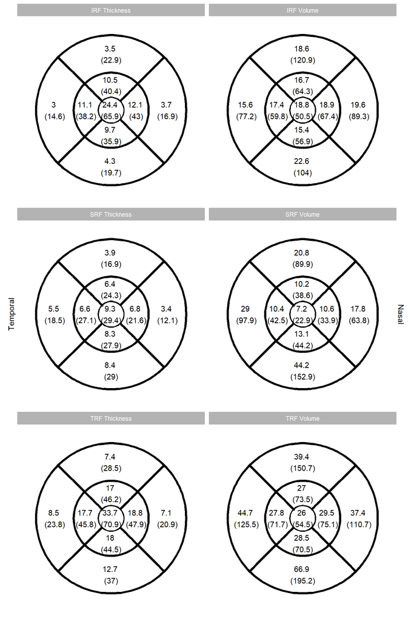

Figure 4.1: Distribution of retinal fluid at baseline by ETDRS grid region: mean (standard deviation). Thicknesses measured in um, volumes in nl.

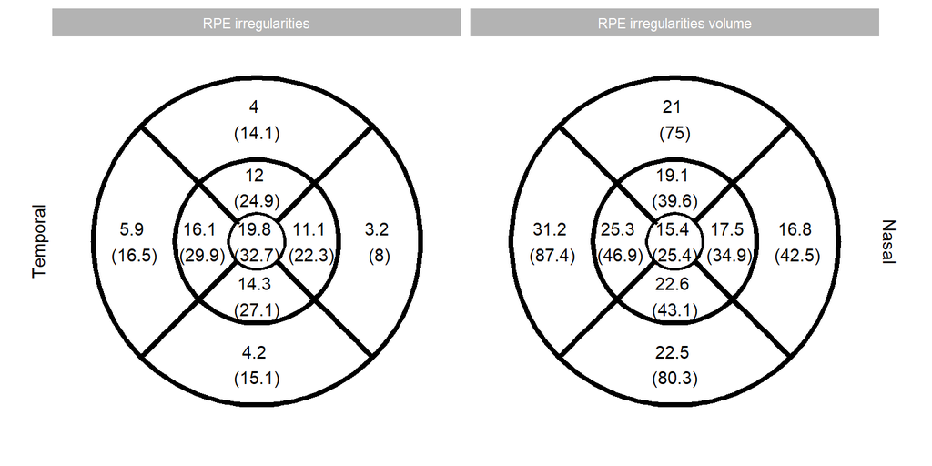

Figure 4.2: Distribution of RPE irregularities at baseline by ETDRS grid region: mean (standard deviation). Thicknesses measured in um, volumes in nl.

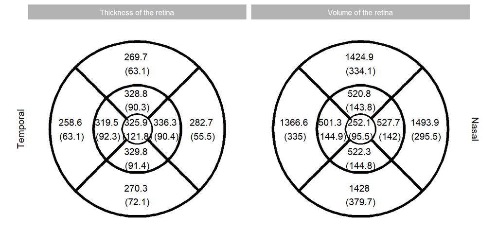

Figure 4.3: Distribution of retinal thickness at baseline by ETDRS grid region: mean (standard deviation). Thicknesses measured in um, volumes in nl.

Table 4.18: Distribution of NOA OCT fluid and retinal measurements at baseline by ETDRS grid region, sorted by strength of correlation with visual acuity.

| Variable | Parameter | Level | Value | n | Correlation with VA | P |
| --- | --- | --- | --- | --- | --- | --- |
| Tempo6[um] | Inner Temporal Sub Field Thickness of the retina (TS) | Median (IQR) | 240 (223, 272) | NA | 0.30 (0.23, 0.36) | <0.001 |
| Tempo6_vol[nl] | Inner Temporal Sub Field Volume of the retina (TS) | Median (IQR) | 1270 (1180, 1440) | NA | 0.30 (0.23, 0.36) | <0.001 |
| Tempo3[um] | Inner Temporal Sub Field Thickness of the retina (TS) | Median (IQR) | 294 (265, 349) | NA | 0.28 (0.21, 0.34) | <0.001 |
| Tempo3_vol[nl] | Inner Temporal Sub Field Volume of the retina (TS) | Median (IQR) | 461 (415, 548) | NA | 0.28 (0.21, 0.34) | <0.001 |
| CST[um] | Central Sub Field Thickness of the retina (CST) | Median (IQR) | 296 (240, 381) | NA | 0.27 (0.20, 0.34) | <0.001 |
| Superior3[um] | Inner Superior Sub Field Thickness of the retina (SS) | Median (IQR) | 306 (273, 357) | NA | 0.27 (0.20, 0.34) | <0.001 |
| Superior3_vol[nl] | Inner Superior Sub Field Volume of the retina | Median (IQR) | 485 (433, 567) | NA | 0.27 (0.20, 0.34) | <0.001 |
| Inferior6[um] | Inner Inferior Sub Field Thickness of the retina (IS) | Median (IQR) | 248 (230, 284) | NA | 0.27 (0.19, 0.33) | <0.001 |
| Inferior6_vol[nl] | Inner Inferior Sub Field Volume of the retina (IS) | Median (IQR) | 1320 (1220, 1510) | NA | 0.26 (0.19, 0.33) | <0.001 |
| Superior6(RPE)[um] | RPE irregularities superior6 (Outer Superior) | Median (IQR) | 0.21 (0, 1.76) | NA | 0.25 (0.18, 0.32) | <0.001 |
| Superior6_vol(RPE)[nl] | RPE irregularities superior6 volume (Outer Superior) | Median (IQR) | 1.09 (0, 9.26) | NA | 0.25 (0.18, 0.32) | <0.001 |
| CSV[nl] | Central Sub Field Volume of the retina | Median (IQR) | 228 (186, 298) | NA | 0.25 (0.18, 0.32) | <0.001 |
| Inferior3[um] | Inner Inferior Sub Field Thickness of the retina (IS) | Median (IQR) | 305 (273, 361) | NA | 0.24 (0.17, 0.31) | <0.001 |
| Inferior3_vol[nl] | Inner Inferior Sub Field Volume of the retina (IS) | Median (IQR) | 485 (432, 571) | NA | 0.24 (0.17, 0.31) | <0.001 |
| Superior6[um] | Inner Superior Sub Field Thickness of the retina (SS) | Median (IQR) | 253 (236, 278) | NA | 0.24 (0.16, 0.31) | <0.001 |
| Superior3(RPE)[um] | RPE irregularities superior3 (Inner Superior) | Median (IQR) | 2.97 (0.25, 12.4) | NA | 0.23 (0.16, 0.30) | <0.001 |
| Superior3_vol(RPE)[nl] | RPE irregularities superior3 volume (Inner Superior) | Median (IQR) | 4.69 (0.4, 19.7) | NA | 0.23 (0.16, 0.30) | <0.001 |
| Nasal3[um] | Inner Nasal Sub Field Thickness of the retina (NS) | Median (IQR) | 312 (279, 373) | NA | 0.23 (0.16, 0.30) | <0.001 |
| Nasal3_vol[nl] | Inner Nasal Sub Field Volume of the retina (NS) | Median (IQR) | 490 (437, 583) | NA | 0.23 (0.16, 0.30) | <0.001 |
| Superior6_vol[nl] | Inner Superior Sub Field Volume of the retina | Median (IQR) | 1340 (1250, 1470) | NA | 0.23 (0.16, 0.30) | <0.001 |
| Inferior6(RPE)[um] | RPE irregularities inferior6 (Outer Inferior) | Median (IQR) | 0.31 (0, 2.24) | NA | 0.22 (0.15, 0.29) | <0.001 |
| Inferior6_vol(RPE)[nl] | RPE irregularities inferior6 volume (Outer Inferior) | Median (IQR) | 1.62 (0, 11.7) | NA | 0.22 (0.15, 0.29) | <0.001 |
| Tempo6(RPE)[um] | RPE irregularities Tempo6 (Outer Temporal) | Median (IQR) | 0.75 (0.07, 3.91) | NA | 0.22 (0.15, 0.29) | <0.001 |
| Tempo6_vol(RPE)[nl] | RPE irregularities Tempo6 volume (Outer Temporal) | Median (IQR) | 3.97 (0.352, 20.8) | NA | 0.22 (0.15, 0.29) | <0.001 |
| Nasal3(RPE)[um] | RPE irregularities Nasal3 (Inner Nasal) | Median (IQR) | 3.28 (0.62, 11.2) | NA | 0.20 (0.13, 0.27) | <0.001 |
| Nasal3_vol(RPE)[nl] | RPE irregularities Nasal3 volume (Inner Nasal) | Median (IQR) | 5.15 (0.97, 17.6) | NA | 0.20 (0.12, 0.27) | <0.001 |
| Inferior3(RPE)[um] | RPE irregularities inferior3 (Inner inferior) | Median (IQR) | 3.86 (0.46, 15.7) | NA | 0.20 (0.13, 0.27) | <0.001 |
| Inferior3_vol(RPE)[nl] | RPE irregularities inferior3 volume (Inner inferior) | Median (IQR) | 6.12 (0.72, 25.1) | NA | 0.20 (0.13, 0.27) | <0.001 |
| Tempo3(RPE)[um] | RPE irregularities Tempo3 (Inner Temporal) | Median (IQR) | 3.97 (0.705, 16.9) | NA | 0.20 (0.13, 0.27) | <0.001 |
| Tempo3_vol(RPE)[nl] | RPE irregularities Tempo3 volume (Inner Temporal) | Median (IQR) | 6.24 (1.1, 26.6) | NA | 0.20 (0.13, 0.27) | <0.001 |

[output cut: 61 more lines]

### 4.4.1 Eyes with SRF and IRF at baseline

Table 4.19: Distribution of NOA OCT fluid measurements at baseline, sorted by strength of correlation with visual acuity. Eyes with SRF and IRF at baseline.

| Variable | Parameter | Level | n | Value | Correlation with VA | P |
| --- | --- | --- | --- | --- | --- | --- |
| MaxIRF_height[um] | Max IRF height | Median (IQR) | NA | 170 (84.2, 279) | 0.25 (0.15, 0.36) | <0.001 |
| PED volume[nl] | Volume of retinal pigment epithelial detachment (PED) | Median (IQR) | NA | 369 (64.3, 1190) | 0.25 (0.14, 0.35) | <0.001 |
| Average_TRF_height[um] | Average TRF height | Median (IQR) | NA | 113 (81, 164) | 0.22 (0.11, 0.32) | <0.001 |
| TRFVolumeNl | TRF Volume | Median (IQR) | NA | 288 (74.6, 762) | 0.20 (0.09, 0.30) | <0.001 |
| Average_IRF_height[um] | Average IRF height | Median (IQR) | NA | 61.8 (37.8, 95.9) | 0.20 (0.09, 0.31) | <0.001 |
| MaxSRF_height[um] | Max SRF height | Median (IQR) | NA | 128 (69.7, 197) | 0.19 (0.08, 0.30) | <0.001 |
| IRFVolumeNl | IRF Volume | Median (IQR) | NA | 44.2 (5.72, 200) | 0.16 (0.05, 0.27) | 0.0040 |
| Average_SRF_height[um] | Average SRF height | Median (IQR) | NA | 46.1 (27.3, 73.6) | 0.15 (0.04, 0.26) | 0.0092 |
| SRFVolumeNl | SRF Volume | Median (IQR) | NA | 122 (20.3, 433) | 0.12 (0.01, 0.23) | 0.0313 |
| SRF | SRF | 1 | 416 (100%) | NA | NA | NA |
| IRF | IRF | 1 | 416 (100%) | NA | NA | NA |
| Fluid | Fluid | 1 | 416 (100%) | NA | NA | NA |
| Eyes | NA |  | 416 (100%) | NA | NA | NA |

Table 4.20: Distribution of NOA OCT fluid and retinal measurements at baseline by ETDRS grid region, sorted by strength of correlation with visual acuity. Eyes with SRF and IRF at baseline.

| Variable | Parameter | Level | Value | n | Correlation with VA | P |
| --- | --- | --- | --- | --- | --- | --- |
| Tempo6_vol[nl] | Inner Temporal Sub Field Volume of the retina (TS) | Median (IQR) | 1360 (1230, 1630) | NA | 0.31 (0.20, 0.41) | <0.001 |
| Tempo6[um] | Inner Temporal Sub Field Thickness of the retina (TS) | Median (IQR) | 257 (232, 309) | NA | 0.30 (0.20, 0.40) | <0.001 |
| Superior6(RPE)[um] | RPE irregularities superior6 (Outer Superior) | Median (IQR) | 0.495 (0, 3.71) | NA | 0.27 (0.16, 0.37) | <0.001 |
| Superior6_vol(RPE)[nl] | RPE irregularities superior6 volume (Outer Superior) | Median (IQR) | 2.63 (0.0175, 19.7) | NA | 0.27 (0.16, 0.37) | <0.001 |
| Tempo3[um] | Inner Temporal Sub Field Thickness of the retina (TS) | Median (IQR) | 330 (286, 406) | NA | 0.26 (0.15, 0.36) | <0.001 |
| Tempo3_vol[nl] | Inner Temporal Sub Field Volume of the retina (TS) | Median (IQR) | 518 (449, 637) | NA | 0.26 (0.15, 0.36) | <0.001 |
| Inferior6_vol[nl] | Inner Inferior Sub Field Volume of the retina (IS) | Median (IQR) | 1420 (1260, 1720) | NA | 0.25 (0.14, 0.35) | <0.001 |
| Superior3[um] | Inner Superior Sub Field Thickness of the retina (SS) | Median (IQR) | 336 (296, 415) | NA | 0.24 (0.13, 0.34) | <0.001 |
| Superior3_vol[nl] | Inner Superior Sub Field Volume of the retina | Median (IQR) | 531 (469, 661) | NA | 0.24 (0.13, 0.34) | <0.001 |
| Superior6[um] | Inner Superior Sub Field Thickness of the retina (SS) | Median (IQR) | 267 (244, 312) | NA | 0.24 (0.13, 0.34) | <0.001 |
| Superior6_vol[nl] | Inner Superior Sub Field Volume of the retina | Median (IQR) | 1410 (1290, 1650) | NA | 0.24 (0.13, 0.34) | <0.001 |
| Inferior6[um] | Inner Inferior Sub Field Thickness of the retina (IS) | Median (IQR) | 270 (239, 321) | NA | 0.24 (0.13, 0.35) | <0.001 |
| Inferior3[um] | Inner Inferior Sub Field Thickness of the retina (IS) | Median (IQR) | 343 (298, 415) | NA | 0.21 (0.10, 0.31) | <0.001 |
| Inferior3_vol[nl] | Inner Inferior Sub Field Volume of the retina (IS) | Median (IQR) | 547 (470, 658) | NA | 0.21 (0.10, 0.31) | <0.001 |
| Superior3(RPE)[um] | RPE irregularities superior3 (Inner Superior) | Median (IQR) | 5.59 (0.8, 18.9) | NA | 0.20 (0.09, 0.31) | <0.001 |
| Superior3_vol(RPE)[nl] | RPE irregularities superior3 volume (Inner Superior) | Median (IQR) | 8.89 (1.27, 29.9) | NA | 0.20 (0.09, 0.31) | <0.001 |
| Inferior6(RPE)[um] | RPE irregularities inferior6 (Outer Inferior) | Median (IQR) | 0.885 (0.04, 5.02) | NA | 0.20 (0.08, 0.30) | <0.001 |
| Inferior6_vol(RPE)[nl] | RPE irregularities inferior6 volume (Outer Inferior) | Median (IQR) | 4.69 (0.238, 26.6) | NA | 0.20 (0.08, 0.30) | <0.001 |
| CST[um] | Central Sub Field Thickness of the retina (CST) | Median (IQR) | 358 (287, 454) | NA | 0.20 (0.09, 0.30) | <0.001 |
| Nasal6(RPE)[um] | RPE irregularities Nasal6 (Outer Nasal) | Median (IQR) | 0.74 (0.09, 4.08) | NA | 0.19 (0.08, 0.30) | <0.001 |
| Nasal6_vol(RPE)[nl] | RPE irregularities Nasal6 volume (Outer Nasal) | Median (IQR) | 3.86 (0.467, 21.6) | NA | 0.19 (0.08, 0.30) | <0.001 |
| Tempo6(RPE)[um] | RPE irregularities Tempo6 (Outer Temporal) | Median (IQR) | 1.25 (0.16, 7.7) | NA | 0.18 (0.07, 0.29) | 0.0017 |
| Tempo6_vol(RPE)[nl] | RPE irregularities Tempo6 volume (Outer Temporal) | Median (IQR) | 6.64 (0.858, 40.9) | NA | 0.18 (0.07, 0.29) | 0.0016 |
| Nasal3[um] | Inner Nasal Sub Field Thickness of the retina (NS) | Median (IQR) | 352 (306, 417) | NA | 0.18 (0.07, 0.29) | 0.0013 |
| Nasal3_vol[nl] | Inner Nasal Sub Field Volume of the retina (NS) | Median (IQR) | 554 (479, 654) | NA | 0.18 (0.07, 0.28) | 0.0017 |
| Tempo3(IRF)[um] | IRF Inner Temporal Sub Field Thickness | Median (IQR) | 0.173 (0, 8.47) | NA | 0.17 (0.05, 0.27) | 0.0037 |
| Tempo6(TRF)[um] | TRF Inner Temporal Sub Field Thickness | Median (IQR) | 1.77 (0, 16.6) | NA | 0.17 (0.06, 0.28) | 0.0027 |
| Tempo6_vol(TRF)[nl] | TRF Inner Temporal Sub Field Volume | Median (IQR) | 9.8 (0, 87.9) | NA | 0.17 (0.06, 0.28) | 0.0025 |
| CSV[nl] | Central Sub Field Volume of the retina | Median (IQR) | 278 (223, 352) | NA | 0.16 (0.05, 0.27) | 0.0043 |
| Superior3(IRF)[um] | IRF Inner Superior Sub Field Thickness | Median (IQR) | 0.174 (0, 7.9) | NA | 0.16 (0.05, 0.27) | 0.0043 |

[output cut: 61 more lines]